# Benchmarking models at locating spatial expression of cell types with scRNA-seq reference and Visium spatial (mouse brain)

```python
import sys, ast, os
import time
import pickle
import scanpy as sc
import anndata
import pandas as pd
import numpy as np
import os
from plotnine import *
import matplotlib.pyplot as plt
import matplotlib
data_type = 'float32'
#os.environ["THEANO_FLAGS"] = 'device=cpu,floatX=' + data_type + ',force_device=True'
os.environ["THEANO_FLAGS"] = 'device=cuda0,floatX=' + data_type + ',force_device=True'
# /nfs/team283/vk7/software/miniconda3farm5/envs/cellpymc/bin/pip install git+https://github.com/vitkl/cell2location.git
sys.path.insert(1, '/nfs/team205/vk7/sanger_projects/cell2location_dev/')
sys.path.insert(1, '/nfs/team205/vk7/sanger_projects/BayraktarLab/cell2location/')

import cell2location.models as c2l
import cell2location.plt as c2lpl
import cell2location.cluster_averages
import cell2location

from matplotlib import rcParams
rcParams['pdf.fonttype'] = 42 # enables correct plotting of text
import seaborn as sns
import itertools

# scanpy prints a lot of warnings
import warnings
warnings.filterwarnings('ignore')
```

```python
import sys
for module in sys.modules:
    try:
        print(module,sys.modules[module].__version__)
    except:
        try:
            if  type(sys.modules[module].version) is str:
                print(module,sys.modules[module].version)
            else:
                print(module,sys.modules[module].version())
        except:
            try:
                print(module,sys.modules[module].VERSION)
            except:
                pass
```

[output not shown]

[output cut: 135 more lines]

[output not shown]

`THEANO_FLAGS='force_device=True'` forces the package to use GPU. Pay attention to error messages that might indicate theano failed to initalise the GPU.  
Do not forget to change `device=cuda4` to your available GPU id. Use `device=cuda` / `device=cuda0` if you have just one locally or if you are requesting one GPU via HPC cluster job.

### The purpose of the notebook is to benchmark several versions of the model using mouse brain data.

```
# extract 2 selected samples
adata_snrna_raw = anndata.read('/nfs/team205/vk7/sanger_projects/cell2location/notebooks/data/mouse_viseum_snrna/rawdata/all_cells_20200625.h5ad')
adata_snrna_raw = adata_snrna_raw[adata_snrna_raw.obs['sample'].isin(['5705STDY8058280', '5705STDY8058281']), :]
adata_snrna_raw.write('/nfs/team205/vk7/sanger_projects/cell2location/notebooks/data/mouse_viseum_snrna/rawdata/5705STDY8058280_5705STDY8058281_20200625.h5ad')

sub_labels = pd.read_csv('/nfs/team205/vk7/sanger_projects/cell2location/notebooks/results/mouse_viseum_snrna/snRNA_annotation_subclusters_20200207.csv',
                     index_col=0)
labels = pd.read_csv('/nfs/team205/vk7/sanger_projects/cell2location/notebooks/results/mouse_viseum_snrna/snRNA_annotation_20200229.csv',
                     index_col=0)

# filter to common cell (one mouse)
labels = labels.loc[labels.index.isin(sub_labels.index)]

# name astrocytes according to subtype labels
sub_labels = sub_labels.reindex(index = labels.index)
astro_ind = labels.index[labels['annotation_1'].isin(['Astro_1', 'Astro_2'])]
labels.loc[astro_ind, 'annotation_1'] = sub_labels.loc[astro_ind, 'annotation_subclusters']

# remove 'NonNeu_' from astro names
from re import sub
labels['annotation_1'] = [sub('NonNeu_', '', i) for i in labels['annotation_1']]


shared_names = adata_snrna_raw.obs_names[adata_snrna_raw.obs_names.isin(labels.index)]
labels = labels.loc[shared_names,]
labels.to_csv('/nfs/team205/vk7/sanger_projects/cell2location/notebooks/results/mouse_viseum_snrna/snRNA_annotation_subclusters_20200207_samples2.csv')
```

```
# Simulate some data
# split simulation and validation scRNA-seq
python split_sc.py /nfs/team205/vk7/sanger_projects/cell2location/notebooks/data/mouse_viseum_snrna/rawdata/all_cells_20200625.h5ad /nfs/team205/vk7/sanger_projects/cell2location/notebooks/results/mouse_viseum_snrna/snRNA_annotation_20200229.csv --annotation_col annotation_1  --out_dir /nfs/team205/vk7/sanger_projects/cell2location/notebooks/data/lowdens_synthetic_ST_fewcells/all_samples/
python split_sc.py /nfs/team205/vk7/sanger_projects/cell2location/notebooks/data/mouse_viseum_snrna/rawdata/5705STDY8058280_5705STDY8058281_20200625.h5ad /nfs/team205/vk7/sanger_projects/cell2location/notebooks/results/mouse_viseum_snrna/snRNA_annotation_subclusters_20200207_samples2.csv --annotation_col annotation_1  --out_dir /nfs/team205/vk7/sanger_projects/cell2location/notebooks/data/lowdens_synthetic_ST_fewcells/samples_2/

# generate types of cell density patterns
export n_spots=2000
export seed=$(ls /nfs/team205/vk7/sanger_projects/cell2location/notebooks/data/lowdens_synthetic_ST_fewcells/all_samples/labels_generation* | sed 's/.*_//' | sed 's/.p//')

python assemble_design.py \
  --tot_spots $n_spots --mean_high 3 --mean_low 1 --annotation_col annotation_1\
  --out_dir /nfs/team205/vk7/sanger_projects/cell2location/notebooks/data/lowdens_synthetic_ST_fewcells/all_samples/ \
  674
python assemble_design.py \
  --tot_spots $n_spots --mean_high 3 --mean_low 1 --annotation_col annotation_1\
  --out_dir /nfs/team205/vk7/sanger_projects/cell2location/notebooks/data/lowdens_synthetic_ST_fewcells/all_samples/ \
  444
python assemble_design.py \
  --tot_spots $n_spots --mean_high 3 --mean_low 1 --annotation_col annotation_1\
  --out_dir /nfs/team205/vk7/sanger_projects/cell2location/notebooks/data/lowdens_synthetic_ST_fewcells/all_samples/ \
  214

export n_spots=2000
export seed=$(ls /nfs/team205/vk7/sanger_projects/cell2location/notebooks/data/lowdens_synthetic_ST_fewcells/samples_2_v2/labels_generation* | sed 's/.*_//' | sed 's/.p//')
python assemble_design.py \
  --tot_spots $n_spots --mean_high 2.5 --mean_low 0.8 --annotation_col annotation_1\
  --out_dir /nfs/team205/vk7/sanger_projects/cell2location/notebooks/data/lowdens_synthetic_ST_fewcells/samples_2_v2/ \
  335
python assemble_design.py \
  --tot_spots $n_spots --mean_high 2.5 --mean_low 0.8 --annotation_col annotation_1\
  --out_dir /nfs/team205/vk7/sanger_projects/cell2location/notebooks/data/lowdens_synthetic_ST_fewcells/samples_2_v2/ \
  604
python assemble_design.py \
  --tot_spots $n_spots --mean_high 2.5 --mean_low 0.8 --annotation_col annotation_1\
  --out_dir /nfs/team205/vk7/sanger_projects/cell2location/notebooks/data/lowdens_synthetic_ST_fewcells/samples_2_v2/ \
  10

# generate the number of cells per spot
id=1
python assemble_composition.py \
    --out_dir /nfs/team205/vk7/sanger_projects/cell2location/notebooks/data/lowdens_synthetic_ST_fewcells/all_samples/\
    --tot_spots $n_spots --assemble_id $id 674
python assemble_composition.py \
    --out_dir /nfs/team205/vk7/sanger_projects/cell2location/notebooks/data/lowdens_synthetic_ST_fewcells/all_samples/\
    --tot_spots $n_spots --assemble_id $id 444
python assemble_composition.py \
    --out_dir /nfs/team205/vk7/sanger_projects/cell2location/notebooks/data/lowdens_synthetic_ST_fewcells/all_samples/\
    --tot_spots $n_spots --assemble_id $id 214


python assemble_composition.py \
    --out_dir /nfs/team205/vk7/sanger_projects/cell2location/notebooks/data/lowdens_synthetic_ST_fewcells/samples_2_v2/\
    --tot_spots $n_spots --assemble_id $id 335
python assemble_composition.py \
    --out_dir /nfs/team205/vk7/sanger_projects/cell2location/notebooks/data/lowdens_synthetic_ST_fewcells/samples_2_v2/\
    --tot_spots $n_spots --assemble_id $id 604
python assemble_composition.py \
    --out_dir /nfs/team205/vk7/sanger_projects/cell2location/notebooks/data/lowdens_synthetic_ST_fewcells/samples_2_v2/\
    --tot_spots $n_spots --assemble_id $id 10

# (Step 4) Assemble simulated ST spots
id=1
python assemble_st.py --out_dir /nfs/team205/vk7/sanger_projects/cell2location/notebooks/data/lowdens_synthetic_ST_fewcells/all_samples/\
  --assemble_id $id 674
id=1
python assemble_st.py --out_dir /nfs/team205/vk7/sanger_projects/cell2location/notebooks/data/lowdens_synthetic_ST_fewcells/all_samples/\
  --assemble_id $id 444
id=1
python assemble_st.py --out_dir /nfs/team205/vk7/sanger_projects/cell2location/notebooks/data/lowdens_synthetic_ST_fewcells/all_samples/\
  --assemble_id $id 214

id=1
python assemble_st.py --out_dir /nfs/team205/vk7/sanger_projects/cell2location/notebooks/data/lowdens_synthetic_ST_fewcells/samples_2_v2/\
  --assemble_id $id 335
id=1
python assemble_st.py --out_dir /nfs/team205/vk7/sanger_projects/cell2location/notebooks/data/lowdens_synthetic_ST_fewcells/samples_2_v2/\
  --assemble_id $id 604
id=1
python assemble_st.py --out_dir /nfs/team205/vk7/sanger_projects/cell2location/notebooks/data/lowdens_synthetic_ST_fewcells/samples_2_v2/\
  --assemble_id $id 10
```

## Load input data

First we load sample annotations.

```python
sp_data_folder = '/nfs/team205/vk7/sanger_projects/cell2location_proj/notebooks/data/lowdens_synthetic_ST_fewcells/samples_2_v2/'
results_folder = '/nfs/team205/vk7/sanger_projects/cell2location_proj/notebooks/results/lowdens_synthetic_ST_fewcells/samples_2/'
```

```python
seed_numbers = ['335', '604', '10']
seed_numbers = seed_numbers[2]
```

```python
# load simulated spatial data desing
design = pd.read_csv(sp_data_folder + 'synthetic_ST_seed'+seed_numbers+'_design.csv',
                    index_col=0)
design.index = ['ref_' + i for i in design.index]
design
```

|  | uniform | density | nspots | mean_ncells |
| --- | --- | --- | --- | --- |
| ref_Astro_3 | 0 | 1.0 | 160.0 | 1.047457 |
| ref_Ext_L25 | 0 | 1.0 | 179.0 | 2.132758 |
| ref_Ext_L6 | 0 | 1.0 | 197.0 | 1.123235 |
| ref_Oligo_2 | 0 | 1.0 | 180.0 | 0.059803 |
| ref_Ext_Hpc_1 | 0 | 1.0 | 145.0 | 1.165331 |
| ref_Inh_Meis2_4 | 0 | 1.0 | 224.0 | 0.899732 |
| ref_Nb_2 | 0 | 0.0 | 182.0 | 1.725271 |
| ref_Ext_L23 | 0 | 0.0 | 184.0 | 2.634801 |
| ref_Inh_Pvalb | 1 | 1.0 | 1729.0 | 1.344651 |
| ref_Inh_Vip | 0 | 1.0 | 218.0 | 0.243348 |
| ref_Ext_L5_1 | 0 | 0.0 | 237.0 | 3.911688 |
| ref_Inh_4 | 0 | 1.0 | 239.0 | 0.770593 |
| ref_Ext_Thal_1 | 0 | 1.0 | 243.0 | 0.328724 |
| ref_Inh_Meis2_3 | 1 | 0.0 | 1480.0 | 3.129082 |
| ref_Ext_Hpc_2 | 0 | 1.0 | 170.0 | 1.953083 |
| ref_Inh_6 | 0 | 1.0 | 226.0 | 1.563946 |
| ref_Inh_3 | 0 | 0.0 | 226.0 | 2.709425 |
| ref_OPC_1 | 0 | 0.0 | 240.0 | 2.497415 |
| ref_Micro | 0 | 0.0 | 261.0 | 2.442353 |
| ref_Ext_Pir | 0 | 1.0 | 210.0 | 1.131038 |
| ref_Astro_0 | 1 | 1.0 | 1646.0 | 0.364592 |
| ref_Unk_1 | 0 | 0.0 | 238.0 | 3.746138 |
| ref_Ext_Hpc_3 | 0 | 1.0 | 168.0 | 0.043921 |
| ref_Ext_Amy_2 | 0 | 1.0 | 186.0 | 0.411793 |
| ref_Inh_Lamp5 | 0 | 1.0 | 182.0 | 0.146687 |
| ref_Inh_2 | 0 | 1.0 | 203.0 | 0.733023 |
| ref_Ext_Unk_3 | 1 | 0.0 | 1619.0 | 3.218297 |
| ref_Ext_Hpc_4 | 0 | 1.0 | 198.0 | 0.906760 |
| ref_Ext_L6B | 0 | 0.0 | 228.0 | 3.727209 |
| ref_Astro_2 | 1 | 1.0 | 1712.0 | 1.117752 |
| ref_LowQ_2 | 0 | 1.0 | 207.0 | 2.327580 |
| ref_Ext_Thal_2 | 0 | 1.0 | 195.0 | 0.453479 |
| ref_Inh_Sst | 0 | 1.0 | 235.0 | 0.167302 |
| ref_Ext_Amy_1 | 0 | 1.0 | 243.0 | 0.723024 |
| ref_Inh_1 | 1 | 1.0 | 1622.0 | 0.297884 |
| ref_Ext_L5_2 | 0 | 1.0 | 158.0 | 0.800948 |
| ref_Ext_L56 | 0 | 1.0 | 151.0 | 0.615454 |
| ref_Inh_5 | 0 | 1.0 | 204.0 | 1.493669 |
| ref_Ext_ClauPyr | 0 | 1.0 | 259.0 | 0.445280 |
| ref_Oligo_1 | 0 | 1.0 | 163.0 | 0.141298 |
| ref_Astro_4 | 1 | 1.0 | 1497.0 | 0.905510 |
| ref_Astro_1 | 0 | 0.0 | 195.0 | 3.967768 |
| ref_Inh_Meis2_2 | 0 | 1.0 | 146.0 | 0.132664 |
| ref_Nb_1 | 0 | 1.0 | 220.0 | 0.086038 |
| ref_Inh_Meis2_1 | 1 | 1.0 | 1531.0 | 0.763334 |
| ref_OPC_2 | 0 | 1.0 | 170.0 | 1.412438 |

```python
# load simulated spatial data
adata = pd.read_csv(sp_data_folder + 'synthetic_ST_seed'+seed_numbers+'_1_counts.csv',
                    index_col=0)

# read the true cell numbers
obs = pd.read_csv(sp_data_folder + 'synthetic_ST_seed'+seed_numbers+'_1_composition.csv',
                    index_col=0)
obs.columns = adata.index

# read the true UMI count
obs_2 = pd.read_csv(sp_data_folder + 'synthetic_ST_seed'+seed_numbers+'_1_umis.csv',
                    index_col=0)
obs_2.columns = ['nUMI_' + i  for i in obs_2.columns]

# create AnnData object
adata = anndata.AnnData(adata, obs=obs.T)
adata.obs[obs_2.columns] = obs_2

# generate random positions
adata.obsm['X_spatial'] = np.array(list(itertools.product(np.arange(np.ceil(np.sqrt(adata.shape[0]))),
                       np.arange(np.ceil(np.sqrt(adata.shape[0]))))))[0:adata.shape[0],:]

design
```

|  | uniform | density | nspots | mean_ncells |
| --- | --- | --- | --- | --- |
| ref_Astro_3 | 0 | 1.0 | 160.0 | 1.047457 |
| ref_Ext_L25 | 0 | 1.0 | 179.0 | 2.132758 |
| ref_Ext_L6 | 0 | 1.0 | 197.0 | 1.123235 |
| ref_Oligo_2 | 0 | 1.0 | 180.0 | 0.059803 |
| ref_Ext_Hpc_1 | 0 | 1.0 | 145.0 | 1.165331 |
| ref_Inh_Meis2_4 | 0 | 1.0 | 224.0 | 0.899732 |
| ref_Nb_2 | 0 | 0.0 | 182.0 | 1.725271 |
| ref_Ext_L23 | 0 | 0.0 | 184.0 | 2.634801 |
| ref_Inh_Pvalb | 1 | 1.0 | 1729.0 | 1.344651 |
| ref_Inh_Vip | 0 | 1.0 | 218.0 | 0.243348 |
| ref_Ext_L5_1 | 0 | 0.0 | 237.0 | 3.911688 |
| ref_Inh_4 | 0 | 1.0 | 239.0 | 0.770593 |
| ref_Ext_Thal_1 | 0 | 1.0 | 243.0 | 0.328724 |
| ref_Inh_Meis2_3 | 1 | 0.0 | 1480.0 | 3.129082 |
| ref_Ext_Hpc_2 | 0 | 1.0 | 170.0 | 1.953083 |
| ref_Inh_6 | 0 | 1.0 | 226.0 | 1.563946 |
| ref_Inh_3 | 0 | 0.0 | 226.0 | 2.709425 |
| ref_OPC_1 | 0 | 0.0 | 240.0 | 2.497415 |
| ref_Micro | 0 | 0.0 | 261.0 | 2.442353 |
| ref_Ext_Pir | 0 | 1.0 | 210.0 | 1.131038 |
| ref_Astro_0 | 1 | 1.0 | 1646.0 | 0.364592 |
| ref_Unk_1 | 0 | 0.0 | 238.0 | 3.746138 |
| ref_Ext_Hpc_3 | 0 | 1.0 | 168.0 | 0.043921 |
| ref_Ext_Amy_2 | 0 | 1.0 | 186.0 | 0.411793 |
| ref_Inh_Lamp5 | 0 | 1.0 | 182.0 | 0.146687 |
| ref_Inh_2 | 0 | 1.0 | 203.0 | 0.733023 |
| ref_Ext_Unk_3 | 1 | 0.0 | 1619.0 | 3.218297 |
| ref_Ext_Hpc_4 | 0 | 1.0 | 198.0 | 0.906760 |
| ref_Ext_L6B | 0 | 0.0 | 228.0 | 3.727209 |
| ref_Astro_2 | 1 | 1.0 | 1712.0 | 1.117752 |
| ref_LowQ_2 | 0 | 1.0 | 207.0 | 2.327580 |
| ref_Ext_Thal_2 | 0 | 1.0 | 195.0 | 0.453479 |
| ref_Inh_Sst | 0 | 1.0 | 235.0 | 0.167302 |
| ref_Ext_Amy_1 | 0 | 1.0 | 243.0 | 0.723024 |
| ref_Inh_1 | 1 | 1.0 | 1622.0 | 0.297884 |
| ref_Ext_L5_2 | 0 | 1.0 | 158.0 | 0.800948 |
| ref_Ext_L56 | 0 | 1.0 | 151.0 | 0.615454 |
| ref_Inh_5 | 0 | 1.0 | 204.0 | 1.493669 |
| ref_Ext_ClauPyr | 0 | 1.0 | 259.0 | 0.445280 |
| ref_Oligo_1 | 0 | 1.0 | 163.0 | 0.141298 |
| ref_Astro_4 | 1 | 1.0 | 1497.0 | 0.905510 |
| ref_Astro_1 | 0 | 0.0 | 195.0 | 3.967768 |
| ref_Inh_Meis2_2 | 0 | 1.0 | 146.0 | 0.132664 |
| ref_Nb_1 | 0 | 1.0 | 220.0 | 0.086038 |
| ref_Inh_Meis2_1 | 1 | 1.0 | 1531.0 | 0.763334 |
| ref_OPC_2 | 0 | 1.0 | 170.0 | 1.412438 |

# downsample simulated data using the gene-specific scaling factors np.random.seed(1) gene_level_alpha_hyp = 0.41885602 gene_level_beta_hyp = 0.9527432 gene_level = np.random.gamma(shape=gene_level_alpha_hyp, scale=1/gene_level_beta_hyp, size=adata.shape[1]) adata.var['gene_level'] = gene_level / 4 adata_downsampled = adata.copy() #adata_downsampled.X = np.random.binomial(adata_downsampled.X \ # * adata_downsampled.var['gene_level'].values.reshape((1, adata.shape[1])), # 1) adata_downsampled.X = np.random.poisson(adata_downsampled.X \ * adata_downsampled.var['gene_level'].values.reshape((1, adata.shape[1]))) adata_downsampled.X.shape # save anndata with sampled gene_levels adata_downsampled.write(sp_data_folder + 'synthetic_ST_seed'+seed_numbers+'_counts_downsampled4.h5ad') adata.write(sp_data_folder + 'synthetic_ST_seed'+seed_numbers+'_counts.h5ad')from scipy.stats import multivariate_normal multivariate_normal.rvs(mean=[0, 0], cov=[[1, 0.5], [0.5, 1]], size=3)from scipy.stats import wishart ws = wishart.rvs(df=design.shape[0]*10, scale=design['mean_ncells'], size=1) np.diag(ws), design['mean_ncells'].values, wsadata.obs.loc[:, np.array(['ref_' in c for c in adata.obs.columns]) \ & ~ np.array(['ref_nUMI' in c for c in adata.obs.columns])]

```python
# read anndata with sampled gene_levels
adata = anndata.read(sp_data_folder + 'synthetic_ST_seed'+seed_numbers+'_counts_downsampled.h5ad')
```

```python
adata.obs.columns = ['ref_' + i for i in adata.obs.columns]
```

```python
#plt.hist(adata.var['gene_level']);
```

```python
# load single cell reference used for simulation (validation set)
counts_validation = pickle.load(open(sp_data_folder + 'counts_validation_'+seed_numbers+'.p', 'rb'))
labels_validation = pickle.load(open(sp_data_folder + 'labels_validation_'+seed_numbers+'.p', 'rb'))
adata_snrna_raw = anndata.AnnData(counts_validation, obs=labels_validation)
```

```python
adata_snrna_raw
```

```
AnnData object with n_obs × n_vars = 8137 × 31053
    obs: 'annotation_1'
```

# bench_exp_dir = '/lustre/scratch117/cellgen/team283/vk7/data_sharing/visium/lowdens_synthetic_ST_fewcells/csv_export/' bench_exp_dir = bench_exp_dir +'seed'+seed_numbers+'/' #os.mkdir(bench_exp_dir) suffix = '_downsampled4' # export spatial data as csv df = pd.DataFrame(adata_downsampled.X) df.columns = adata_downsampled.var_names df.index = adata_downsampled.obs.index df.index.name = 'spot' df.to_csv(bench_exp_dir + 'sp_data' + suffix + '.tsv', sep='\t')# Now we export data for stereoscope and Seurat CCA approach bench_exp_dir = '/lustre/scratch117/cellgen/team283/vk7/data_sharing/visium/lowdens_synthetic_ST_fewcells/csv_export/' bench_exp_dir = bench_exp_dir +'seed'+seed_numbers+'/' os.mkdir(bench_exp_dir) suffix = '' # export spatial data as csv df = pd.DataFrame(adata.X) df.columns = adata.var_names df.index = adata.obs.index df.index.name = 'spot' df.to_csv(bench_exp_dir + 'sp_data' + suffix + '.tsv', sep='\t') suffix = '_downsampled' # export spatial data as csv df = pd.DataFrame(adata_downsampled.X) df.columns = adata_downsampled.var_names df.index = adata_downsampled.obs.index df.index.name = 'spot' df.to_csv(bench_exp_dir + 'sp_data' + suffix + '.tsv', sep='\t') # save expression matrix df = pd.DataFrame(adata_snrna_raw.X) df.columns = adata_snrna_raw.var_names df.index = adata_snrna_raw.obs.index df.index.name = 'cell' df.to_csv(bench_exp_dir + 'sc_reference.tsv', sep='\t') # save df = adata_snrna_raw.obs[['annotation_1']] df.rename(columns={'annotation_1': 'bio_celltype'}, inplace=True) df.index.name = 'cell' df.to_csv(bench_exp_dir + 'sc_reference_annot.tsv', sep='\t') bench_exp_dir

```python
sc.pp.calculate_qc_metrics(adata, inplace=True)

# read the remaining samples
slides = {'seed'+seed_numbers: adata}

adata_0 = adata.copy()
```

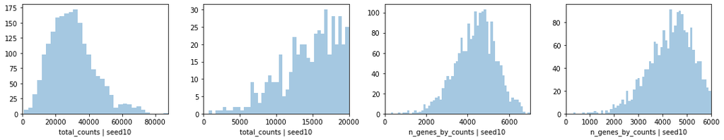

```python
# PLOT QC FOR EACH SAMPLE
if len(slides) > 2:
    figsize = 4*len(slides)-4
else:
    figsize = 4*len(slides)-1

fig, axs = plt.subplots(len(slides), 4, figsize=(15, figsize))
axs = axs.reshape((len(slides), 4))
for i in range(len(slides)):
    #fig.suptitle('Covariates for filtering')

    sns.distplot(list(slides.values())[i].obs['total_counts'],
                 kde=False, ax = axs[i, 0])
    axs[i, 0].set_xlim(0, adata.obs['total_counts'].max())
    axs[i, 0].set_xlabel('total_counts | ' + list(slides.keys())[i])

    sns.distplot(list(slides.values())[i].obs['total_counts']\
                 [list(slides.values())[i].obs['total_counts']<20000],
                 kde=False, bins=40, ax = axs[i, 1])
    axs[i, 1].set_xlim(0, 20000)
    axs[i, 1].set_xlabel('total_counts | ' + list(slides.keys())[i])

    sns.distplot(list(slides.values())[i].obs['n_genes_by_counts'],
                 kde=False, bins=60, ax = axs[i, 2])
    axs[i, 2].set_xlim(0, adata.obs['n_genes_by_counts'].max())
    axs[i, 2].set_xlabel('n_genes_by_counts | ' + list(slides.keys())[i])

    sns.distplot(list(slides.values())[i].obs['n_genes_by_counts']\
                 [list(slides.values())[i].obs['n_genes_by_counts']<6000],
                 kde=False, bins=60, ax = axs[i, 3])
    axs[i, 3].set_xlim(0, 6000)
    axs[i, 3].set_xlabel('n_genes_by_counts | ' + list(slides.keys())[i])

plt.tight_layout()
```

rcParams["axes.facecolor"] = "black" rcParams["figure.figsize"] = [6,7] rcParams["font.size"] = 18 sc.pl.spatial(adata[adata.obs["sample"]==adata.obs["sample"].unique()[0], :], color=["Rorb", "Vip"], img_key=None, vmin=0, cmap='magma', #vmax=3.8, gene_symbols='SYMBOL' )

```python
import scipy
adata_snrna_raw.X = scipy.sparse.csr_matrix(adata_snrna_raw.X)
```

```python
import scipy
adata.X = scipy.sparse.csr_matrix(adata.X)
```

# Select genes expressed by at least 2% of cells in each cluster. adata_snrna_raw_bin = adata_snrna_raw.copy() adata_snrna_raw_bin.X = adata_snrna_raw_bin.X > 0 adata_snrna_raw_bin.raw = adata_snrna_raw_bin prop_expressed = cell2location.cluster_averages.cluster_averages.get_cluster_averages(adata_snrna_raw_bin, 'annotation_1') prop_expressed = prop_expressed.loc[adata_snrna_raw.var_names,:] adata_snrna_raw = adata_snrna_raw[:, prop_expressed.max(1) > 0.02]

Select genes using expression in non-zero cells

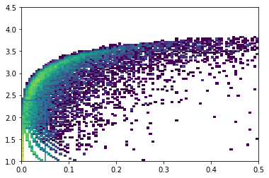

```python
# Select cells
#min_genes = 1000
rcParams["axes.facecolor"] = "white"

sc.pp.filter_cells(adata_snrna_raw, min_genes=1)
sc.pp.filter_genes(adata_snrna_raw, min_cells=1)

# calculate the mean of each gene across non-zero cells
adata_snrna_raw.var['n_cells'] = (adata_snrna_raw.X.toarray() > 0).sum(0)
adata_snrna_raw.var['nonz_mean'] = adata_snrna_raw.X.toarray().sum(0) / adata_snrna_raw.var['n_cells']

plt.hist2d(np.log10(adata_snrna_raw.var['nonz_mean']),
           np.log10(adata_snrna_raw.var['n_cells']), bins=100,
           norm=matplotlib.colors.LogNorm(),
           range=[[0,0.5], [1,4.5]]);
nonz_mean_cutoff = 0.05
cell_count_cutoff = np.log10(adata_snrna_raw.shape[0] * 0.001)
cell_count_cutoff2 = np.log10(adata_snrna_raw.shape[0] * 0.03)
plt.vlines(nonz_mean_cutoff, cell_count_cutoff, cell_count_cutoff2);
plt.hlines(cell_count_cutoff, nonz_mean_cutoff, 1);
plt.hlines(cell_count_cutoff2, 0, nonz_mean_cutoff);
```

```python
adata_snrna_raw[:,(np.array(np.log10(adata_snrna_raw.var['nonz_mean']) > nonz_mean_cutoff)
         | np.array(np.log10(adata_snrna_raw.var['n_cells']) > cell_count_cutoff2))
      & np.array(np.log10(adata_snrna_raw.var['n_cells']) > cell_count_cutoff)].shape
```

```
(8137, 12281)
```

```python
# select genes based on mean expression in non-zero cells
adata_snrna_raw = adata_snrna_raw[:,(np.array(np.log10(adata_snrna_raw.var['nonz_mean']) > nonz_mean_cutoff)
         | np.array(np.log10(adata_snrna_raw.var['n_cells']) > cell_count_cutoff2))
      & np.array(np.log10(adata_snrna_raw.var['n_cells']) > cell_count_cutoff)]
```

```python
adata_snrna_raw
```

```
View of AnnData object with n_obs × n_vars = 8137 × 12281
    obs: 'annotation_1', 'n_genes'
    var: 'n_cells', 'nonz_mean'
```

Add counts matrix as `adata.raw`

```python
adata_snrna_raw.raw = adata_snrna_raw
```

```python
adata_vis = adata.copy()
adata_vis.raw = adata_vis
```

#### Plot numbers of cells per spot

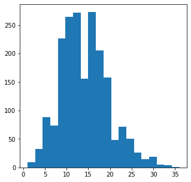

```python
rcParams['figure.figsize'] = 5, 5
cell_count = adata.obs.loc[:, [('ref_' in i) & ('nUMI' not in i)
                               for i in adata.obs.columns]]
plt.hist(cell_count.sum(1), bins=20);
```

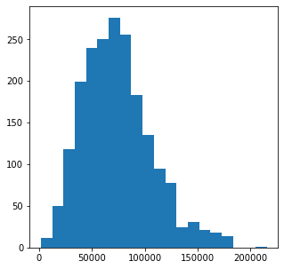

```python
umi_count = adata.obs.loc[:, [('ref_' in i) & ('nUMI' in i)
                               for i in adata.obs.columns]]
plt.hist(umi_count.sum(1), bins=20);
```

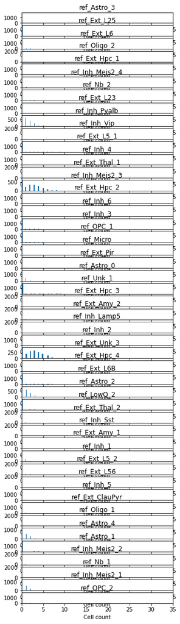

```python
rcParams['figure.figsize'] = 5, 20
for i, c in enumerate(cell_count.columns):
    plt.subplot(cell_count.shape[1], 1, i+1)
    plt.hist(cell_count[c], bins = 35);
    plt.xlabel('Cell count');
    plt.xlim(0, 35);
    plt.title(str(c));
plt.tight_layout()
```

```python
adata_vis.var['ENSEMBL'] = adata_vis.var_names
adata_vis.obs['sample'] = 'sample'
```

```python
from re import sub
adata_snrna_raw.obs['sample'] = [sub('_.+$','', i) for i in adata_snrna_raw.obs.index]
```

## Show UMAP of cells and locations

sc.pp.log1p(adata_snrna_raw)

# sc.pp.highly_variable_genes(adata_snrna_raw, min_mean=0.0125, max_mean=5, min_disp=0.5)

sc.pp.scale(adata_snrna_raw, max_value=10) sc.tl.pca(adata_snrna_raw, svd_solver='arpack', n_comps=70, use_highly_variable=False) sc.pp.neighbors(adata_snrna_raw, n_neighbors = 15, n_pcs = 70, metric='cosine')

# bbknn.bbknn(adata_snrna_raw, batch_key='sample_id')

sc.tl.umap(adata_snrna_raw, min_dist = 0.8, spread = 1.5)

# sc.pp.neighbors(adata_snrna_raw, n_neighbors = 100, n_pcs = 100)

# bbknn.bbknn(adata_snrna_raw, neighbors_within_batch = 3, batch_key = 'sample', n_pcs = 50)

# sc.tl.umap(adata_snrna_raw, min_dist = 0.5, spread = 1)

rcParams['figure.figsize'] = 10, 10 rcParams["axes.facecolor"] = "white" sc.pl.umap(adata_snrna_raw, color=['annotation_1'], color_map = 'RdPu', ncols = 1, legend_loc='on data', legend_fontsize=10)

Now we look at the UMAP of Visium spots

sc.tl.pca(adata_vis, svd_solver='arpack', n_comps=50) sc.pp.neighbors(adata_vis, n_neighbors = 100, n_pcs = 50) sc.tl.umap(adata_vis, min_dist = 0.2, spread = 4) # Cluster spots into regions using scanpy sc.tl.leiden(adata_vis, resolution=1.3) rcParams['figure.figsize'] = 10, 10 rcParams["axes.facecolor"] = "white" sc.pl.umap(adata_vis, color=['leiden'], color_map = 'RdPu', ncols = 1, legend_loc='on data', legend_fontsize=10)

### First, infer average expression in each cell type

```python
adata_snrna_raw
```

```
AnnData object with n_obs × n_vars = 8137 × 12281
    obs: 'annotation_1', 'n_genes', 'sample'
    var: 'n_cells', 'nonz_mean'
```

```
from cell2location import run_regression
r, adata_snrna_raw = run_regression(adata_snrna_raw,
                   model_name='RegressionNBV2Torch',
                   verbose=True, return_all=True,

                   train_args={
                    'covariate_col_names': ['annotation_1'],
                    'sample_name_col': 'sample',
                    'tech_id': None,
                    'stratify_cv': 'annotation_1',

                    'n_epochs': 100, 'minibatch_size': 1024, 'learning_rate': 0.01,

                    'use_average_as_initial_value': True, 'use_cuda': True,

                    'train_proportion': 0.9,
                    'l2_weight': {'l2_weight': 0.001, 'sample_scaling_weight': 0.5,
                           'gene_overdisp_weight': 0.1},  # True = use defaults for the model

                    'readable_var_name_col': None, 'use_raw': True},

                   model_kwargs={},
                   posterior_args={},

                   export_args={'path': results_folder + 'regression_model/', 'save_model': True,
                                'run_name_suffix': ''})

reg_mod = r['mod']
#adata_snrna_raw = r['sc_data']
```

```python
reg_mod_name = 'RegressionNBV2Torch_48covariates_8137cells_12281genes'
reg_path = f'{results_folder}regression_model/{reg_mod_name}/'

adata_snrna_raw = sc.read(f'{reg_path}sc.h5ad')
#r = pickle.load(file = open(f'{reg_path}model_.p', "rb"))
#reg_mod = r['mod']
```

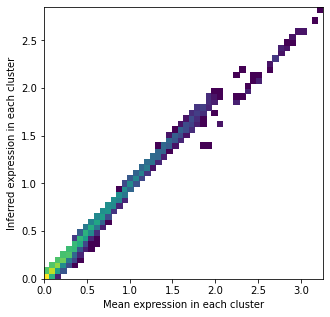

```python
# export inferred averages in each cluster
inf_aver = pd.DataFrame(#adata_snrna_raw.uns['regression_mod']['post_sample_q05']['gene_factors'].T,
                        adata_snrna_raw.uns['regression_mod']['post_sample_means']['gene_factors'].T,
             index=adata_snrna_raw.uns['regression_mod']['var_names'],
             columns=adata_snrna_raw.uns['regression_mod']['fact_names'])
inf_aver = inf_aver.loc[:, np.array(['annotation_1_' in i for i in inf_aver.columns])]
from re import sub
inf_aver.columns = [sub('annotation_1_', '', i) for i in inf_aver.columns]
inf_aver = inf_aver.iloc[:, inf_aver.columns.argsort()]

# scale up by average sample scaling factor
inf_aver = inf_aver * adata_snrna_raw.uns['regression_mod']['post_sample_means']['sample_scaling'].mean()

# compute mean expression of each gene in each cluster
aver = cell2location.cluster_averages.cluster_averages.get_cluster_averages(adata_snrna_raw, 'annotation_1')
aver = aver.loc[adata_snrna_raw.var_names, inf_aver.columns]

# export inferred averages in each cluster
#inf_aver = reg_mod.covariate_effects.copy()
#from re import sub
#inf_aver.columns = [sub('mean_cov_effect_Subset_', '', i) for i in inf_aver.columns]
#inf_aver = inf_aver.loc[aver.index, aver.columns]

rcParams['figure.figsize'] = 5, 5
plt.hist2d(np.log10(aver.values.flatten()+1), np.log10(inf_aver.values.flatten()+1),
           bins=50, norm=matplotlib.colors.LogNorm());
plt.xlabel('Mean expression in each cluster');
plt.ylabel('Inferred expression in each cluster');
```

```python
inf_aver
```

|  | Astro_0 | Astro_1 | Astro_2 | Astro_3 | Astro_4 | Ext_Amy_1 | Ext_Amy_2 | Ext_ClauPyr | Ext_Hpc_1 | Ext_Hpc_2 | ... | Inh_Vip | LowQ_2 | Micro | Nb_1 | Nb_2 | OPC_1 | OPC_2 | Oligo_1 | Oligo_2 | Unk_1 |
| --- | --- | --- | --- | --- | --- | --- | --- | --- | --- | --- | --- | --- | --- | --- | --- | --- | --- | --- | --- | --- | --- |
| ENSMUSG00000051951 | 0.022486 | 0.016976 | 0.086153 | 0.041645 | 7.841317e-09 | 15.194770 | 12.538737 | 4.215148 | 7.860838 | 13.571537 | ... | 5.214285 | 4.136590 | 2.167259e-02 | 1.177524 | 0.209740 | 1.497111 | 0.490378 | 1.797966 | 0.580106 | 1.156588 |
| ENSMUSG00000089699 | 0.003711 | 0.002256 | 0.007336 | 0.025868 | 3.093109e-02 | 3.276940 | 2.852150 | 1.129400 | 1.778715 | 2.384050 | ... | 1.112758 | 1.197040 | 7.095898e-09 | 0.619586 | 0.104040 | 0.391304 | 0.073090 | 0.560728 | 0.135010 | 0.210410 |
| ENSMUSG00000033845 | 0.042481 | 0.072505 | 0.035373 | 0.079985 | 4.931773e-02 | 0.252719 | 0.201835 | 0.188274 | 0.144280 | 0.365312 | ... | 0.056814 | 0.044166 | 4.243574e-02 | 0.079114 | 0.064502 | 0.057116 | 0.038589 | 0.073402 | 0.054525 | 0.021059 |
| ENSMUSG00000033813 | 0.111184 | 0.085064 | 0.109497 | 0.122533 | 2.128862e-02 | 0.165481 | 0.164493 | 0.104745 | 0.165570 | 0.248927 | ... | 0.132924 | 0.271114 | 8.407845e-02 | 0.097186 | 0.029543 | 0.095502 | 0.099807 | 0.096890 | 0.049239 | 0.013652 |
| ENSMUSG00000002459 | 2.586503 | 0.938645 | 4.224512 | 1.497234 | 2.246430e+00 | 0.546757 | 0.562627 | 1.241626 | 0.123318 | 0.104664 | ... | 0.240054 | 0.057852 | 8.467723e-03 | 0.074956 | 0.299449 | 0.453870 | 0.098858 | 0.075901 | 0.006583 | 0.085499 |
| ... | ... | ... | ... | ... | ... | ... | ... | ... | ... | ... | ... | ... | ... | ... | ... | ... | ... | ... | ... | ... | ... |
| ENSMUSG00000064370 | 0.201819 | 0.076935 | 0.089152 | 0.005840 | 8.023349e-09 | 0.348742 | 0.291074 | 0.315242 | 0.121683 | 0.110016 | ... | 0.204742 | 0.168578 | 3.789560e-02 | 0.088139 | 0.029742 | 0.111364 | 0.125249 | 0.025911 | 0.058576 | 0.014941 |
| ENSMUSG00000051412 | 0.031819 | 0.036382 | 0.015000 | 0.029460 | 7.998215e-09 | 0.015408 | 0.088058 | 0.023828 | 0.095689 | 0.138790 | ... | 0.117163 | 0.013502 | 7.847074e-03 | 0.094277 | 0.048132 | 0.042530 | 0.083835 | 0.092847 | 0.048933 | 0.003277 |
| ENSMUSG00000079834 | 0.121683 | 0.189370 | 0.321544 | 0.277750 | 4.568088e-02 | 0.300070 | 0.424299 | 0.371203 | 0.163733 | 0.465729 | ... | 0.342700 | 0.113279 | 5.868919e-02 | 0.064777 | 0.025828 | 0.147120 | 0.146925 | 0.167047 | 0.080244 | 0.058513 |
| ENSMUSG00000095041 | 0.188938 | 0.175850 | 0.194827 | 0.208523 | 5.072923e-02 | 1.711358 | 1.793614 | 2.606221 | 2.706197 | 2.911099 | ... | 0.908492 | 1.756510 | 9.975887e-01 | 0.997305 | 0.207220 | 0.322694 | 0.500456 | 0.174653 | 0.103910 | 0.115852 |
| ENSMUSG00000063897 | 0.015431 | 0.033041 | 0.017138 | 0.063019 | 3.610925e-02 | 0.076620 | 0.077367 | 0.073613 | 0.071130 | 0.041611 | ... | 0.068936 | 0.031017 | 3.480173e-02 | 0.115953 | 0.030007 | 0.047632 | 0.022309 | 0.031656 | 0.027520 | 0.007063 |

12281 rows × 46 columns

rcParams['figure.figsize'] = 5, 5 reg_mod.align_plot_stability(aver, aver, 'cluster_average', 'cluster_average', align=False)rcParams['figure.figsize'] = 5, 5 reg_mod.align_plot_stability(inf_aver, inf_aver, 'inferred_average', 'inferred_average', align=False)rcParams['figure.figsize'] = 5, 5 snrna_cell_count = adata_snrna_raw.obs['sample'].value_counts() snrna_cell_count.index = ['mean_sample_effectsample_' + i for i in snrna_cell_count.index] soup_amount = reg_mod.sample_effects.sum(0) plt.scatter(snrna_cell_count[soup_amount.index].values.flatten(), soup_amount.values.flatten()); plt.xlabel('Cell count per sample'); # fraction of reads in cells plt.ylabel('Inferred sum of sample effects');# prior for overdispersion reg_mod.samples['post_sample_means']['phi_hyp']def compare_oversipersion(shape, inferred_shape, aver, nrow=1, ncol=3): res = {} plt.subplot(nrow, ncol, 1) x = shape.max(1).values.flatten() res['max'] = x plt.hist2d(x, inferred_shape.flatten(), bins=[35, 41], norm=matplotlib.colors.LogNorm()); plt.xlabel('Analytic shape (max across clusters)'); plt.ylabel('Inferred shape'); plt.title('Overdispersion, cor: ' \ + str(np.round(np.corrcoef(x, inferred_shape.flatten()), 3)[0,1])); plt.subplot(nrow, ncol, 2) x = shape.mean(1).values.flatten() res['mean'] = x plt.hist2d(x, inferred_shape.flatten(), bins=[35, 41], norm=matplotlib.colors.LogNorm()); plt.xlabel('Analytic shape (mean across clusters)'); plt.ylabel('Inferred shape'); plt.title('Overdispersion, cor: ' \ + str(np.round(np.corrcoef(x, inferred_shape.flatten()), 3)[0,1])); plt.subplot(nrow, ncol, 3) max_ind = np.argmax(aver.values, axis=1) x = np.array([shape.values[i, max_ind[i]] for i in range(aver.shape[0])]) res['max_mean'] = x plt.hist2d(x, inferred_shape.flatten(), bins=[35, 41], norm=matplotlib.colors.LogNorm()); plt.xlabel('Analytic shape (in cluster with max mean)'); plt.ylabel('Inferred shape'); plt.title('Overdispersion, cor: ' \ + str(np.round(np.corrcoef(x, inferred_shape.flatten()), 3)[0,1])); return res# from cell2location.cluster_averages.cluster_averages import get_cluster_averages from cell2location.cluster_averages.cluster_averages import get_cluster_variances eps = 1e-8 aver = get_cluster_averages(adata_snrna_raw, 'annotation_1') + eps variances = get_cluster_variances(adata_snrna_raw, 'annotation_1') + eps shape = aver ** 2 / variances

rcParams['figure.figsize'] = 13, 4.5 rcParams["axes.facecolor"] = "white"

inferred_shape = 1 / (reg_mod.samples['post_sample_means']['gene_E'] \

```
                  * reg_mod.samples['post_sample_means']['gene_E'])
```

res = compare_oversipersion(shape, inferred_shape, aver, nrow=1, ncol=3) plt.tight_layout()

overdisp_mean = shape.mean(1).values.reshape((1, adata_snrna_raw.shape[1])) #overdisp_prior = np.sqrt(1 / overdisp_mean) # get gene_E ~ Exponential() #overdisp_prior = 1 / overdisp_prior # get exponential rate overdisp_mean.shape# export inferred shapes & compute variance in each cluster inf_alpha = reg_mod.covariate_alphas.copy() from re import sub inf_alpha.columns = [sub('mean_cov_alphas_annotation_1_', '', i) for i in inf_alpha.columns] inf_alpha = inf_alpha.loc[aver.index, aver.columns] inf_alpha = 1 / (inf_alpha * inf_alpha) #compute variance inf_var = inf_aver * inf_aver / inf_alpha inf_var

## Model training

`pycell2location.run_cell2location` is a wrapper for cell2location model workflow: We summarise single cell data, train the model, sample prior and posterior, save and export results, including diagnostic plots.

`pycell2location.run_cell2location` takes single cell and spatial anndata as input together with a bunch of parameters.

```python
results_folder
```

```
'/nfs/team205/vk7/sanger_projects/cell2location_proj/notebooks/results/lowdens_synthetic_ST_fewcells/samples_2/'
```

```python
rcParams['figure.figsize'] = 5, 5
from cell2location.models.LocationModelLinearDependentWPyro import LocationModelLinearDependentWPyro
r = cell2location.run_cell2location(
                      sc_data=inf_aver,
                      sp_data=adata_vis,
                      model_name=LocationModelLinearDependentWPyro,
                      verbose=True, return_all=True,

                      summ_sc_data_args={'cluster_col': "annotation_1"},

                      train_args={'n_iter': 30000, 'learning_rate': 0.005,
                                  'sample_prior': False, 'n_prior_samples': 20,
                                  'readable_var_name_col': "ENSEMBL",
                                  'sample_name_col': 'sample', 'method': 'advi'},

                      posterior_args={'n_samples': 1000},
                      export_args={'path': results_folder + 'models/',
                                   'save_model': False, 'run_name_suffix': '_n_comb60_lr0005_n_iter30k_mean_var5_ceps9_cps4_fps5_inf_shape01_gl2',
                                   'scanpy_coords_name': 'X_spatial', 'export_q05': True},
                      model_kwargs={
                                    'cell_number_prior': {'cells_per_spot': 9, 'factors_per_spot': 5,
                                                          'combs_per_spot': 4
                                                         },
                                    'cell_number_var_prior': {
                                                   'cells_mean_var_ratio': 0.5,
                                                   'factors_mean_var_ratio': 1,
                                                   'combs_mean_var_ratio': 1
                                    },
                                    'gene_level_prior':{'mean': 1/2, 'sd': 1/4},
                                    'gene_level_var_prior': {'mean_var_ratio': 0.5},
                                    'n_comb': 60, 'spot_fact_mean_var_ratio': 5,
                                    'phi_hyp_prior':{'mean': 2, 'sd': 1}}
)
```

```
### Summarising single cell clusters ###
### Creating model ### - time 0.01 min
### Analysis name: LocationModelLinearDependentWPyro_46clusters_2000locations_12281genes_n_comb60_lr0005_n_iter30k_mean_var5_ceps9_cps4_fps5_inf_shape01_gl2
### Training model ###
```

```
None
### Sampling posterior ### - time 35.33 min
```

```
### Saving results ###
```

```
... storing 'sample' as categorical
```

```
### Ploting results ###
### Plotting posterior of W / cell locations ###
### Done ### - time 37.09 min
```

```python
rcParams['figure.figsize'] = 5, 5
from cell2location.models.LocationModelLinearDependentWPyro import LocationModelLinearDependentWPyro
r1 = cell2location.run_cell2location(
                      sc_data=inf_aver,
                      sp_data=adata_vis,
                      model_name=LocationModelLinearDependentWPyro,
                      verbose=True, return_all=True,

                      summ_sc_data_args={'cluster_col': "annotation_1"},

                      train_args={'n_iter': 30000, 'learning_rate': 0.005,
                                  'sample_prior': False, 'n_prior_samples': 20,
                                  'readable_var_name_col': "ENSEMBL", 'mode': 'tracking',
                                  'sample_name_col': 'sample', 'method': 'advi'},

                      posterior_args={'n_samples': 1000},
                      export_args={'path': results_folder + 'models/',
                                   'save_model': False, 'run_name_suffix': '_n_comb60_lr0005_n_iter30k_mean_var5_ceps9_cps4_fps5_inf_shape01_gl2',
                                   'scanpy_coords_name': 'X_spatial', 'export_q05': True},
                      model_kwargs={
                                    'cell_number_prior': {'cells_per_spot': 9, 'factors_per_spot': 5,
                                                          'combs_per_spot': 4
                                                         },
                                    'cell_number_var_prior': {
                                                   'cells_mean_var_ratio': 0.5,
                                                   'factors_mean_var_ratio': 1,
                                                   'combs_mean_var_ratio': 1
                                    },
                                    'gene_level_prior':{'mean': 1/2, 'sd': 1/4},
                                    'gene_level_var_prior': {'mean_var_ratio': 0.5},
                                    'n_comb': 60, 'spot_fact_mean_var_ratio': 5,
                                    'phi_hyp_prior':{'mean': 2, 'sd': 1}}
)
```

```
### Summarising single cell clusters ###
### Creating model ### - time 0.01 min
### Analysis name: LocationModelLinearDependentWPyro_46clusters_2000locations_12281genes_n_comb60_lr0005_n_iter30k_mean_var5_ceps9_cps4_fps5_inf_shape01_gl2
### Training model ###
```

```
None
### Sampling posterior ### - time 62.79 min
```

```
### Saving results ###
```

```
... storing 'sample' as categorical
```

```
### Ploting results ###
### Plotting posterior of W / cell locations ###
### Done ### - time 64.57 min
```

```python
r1 = r.copy()
```

```python
rcParams['figure.figsize'] = 5, 5
from cell2location.models.LocationModelLinearDependentW import LocationModelLinearDependentW
r = cell2location.run_cell2location(
                      sc_data=inf_aver,
                      sp_data=adata_vis,
                      model_name=LocationModelLinearDependentW,
                      verbose=True, return_all=True,

                      summ_sc_data_args={'cluster_col': "annotation_1"},

                      train_args={'n_iter': 30000, 'learning_rate': 0.005,
                                  'sample_prior': False, 'n_prior_samples': 20,
                                  'readable_var_name_col': "ENSEMBL",
                                  'sample_name_col': 'sample', 'method': 'advi'},

                      posterior_args={'n_samples': 1000},
                      export_args={'path': results_folder + 'models/',
                                   'save_model': False, 'run_name_suffix': '_n_comb60_lr0005_n_iter30k_mean_var5_ceps9_cps4_fps5_inf_shape01_gl2',
                                   'scanpy_coords_name': 'X_spatial', 'export_q05': True},
                      model_kwargs={
                                    'cell_number_prior': {'cells_per_spot': 9, 'factors_per_spot': 5,
                                                          'combs_per_spot': 4
                                                         },
                                    'cell_number_var_prior': {
                                                   'cells_mean_var_ratio': 0.5,
                                                   'factors_mean_var_ratio': 1,
                                                   'combs_mean_var_ratio': 1
                                    },
                                    'gene_level_prior':{'mean': 1/2, 'sd': 1/4},
                                    'gene_level_var_prior': {'mean_var_ratio': 0.5},
                                    'n_comb': 60, 'spot_fact_mean_var_ratio': 5,
                                    'phi_hyp_prior':{'mean': 2, 'sd': 1}}
)
```

```
### Summarising single cell clusters ###
### Creating model ### - time 0.01 min
### Analysis name: LocationModelLinearDependentW_46clusters_2000locations_12281genes_n_comb60_lr0005_n_iter30k_mean_var5_ceps9_cps4_fps5_inf_shape01_gl2
### Training model ###
```

100.00% [30000/30000 08:38<00:00 Average Loss = 2.3775e+07]

```
Finished [100%]: Average Loss = 2.3775e+07
```

100.00% [30000/30000 08:37<00:00 Average Loss = 2.3776e+07]

```
Finished [100%]: Average Loss = 2.3776e+07
```

```
### Sampling posterior ### - time 18.62 min
```

```
### Saving results ###
```

```
... storing 'sample' as categorical
```

```
### Ploting results ###
### Plotting posterior of W / cell locations ###
### Done ### - time 19.71 min
```

## Evaluate inferred cell density (`spot_factors`) and mRNA count (`nUMI_factors`)

```python
r = {'run_name': 'LocationModelPyroNB4V7_V4_V4_46clusters_2000locations_12281genes_n_comb30_mean_var05_ceps_var1_ceps9_cps2_fps5_inf_shape01_gl1'}
r = {'run_name': 'LocationModelPyro2NB4V7_V4_V4_46clusters_2000locations_12281genes_fulldata'}
#r = {'run_name': 'LocationModelPyro2NB4V7_V4_V4_46clusters_2000locations_12281genes_minibatch'}
r = {'run_name': 'LocationModelLinearDependentWPyro_46clusters_2000locations_12281genes_n_comb60_lr0005_n_iter30k_mean_var5_ceps9_cps4_fps5_inf_shape01_gl2'}


fig_path=results_folder + 'models/' +r['run_name']+'/plots'

sp_data_file = results_folder + 'models/' +r['run_name']+'/sp.h5ad'
adata_vis_res = anndata.read(sp_data_file)
```

```python
file = results_folder + 'models/' + r['run_name']+'/model_.p'
r = pickle.load(file = open(file, "rb"))
```

```python
# look at NBoverdispersion hyperprior
adata_vis_res.uns['mod']['post_sample_means']['phi_hyp']
```

```
array([[1.3274163]], dtype=float32)
```

```python
rcParams['figure.figsize'] = 13, 4.5
rcParams["axes.facecolor"] = "white"

inferred_shape = 1 / (adata_vis_res.uns['mod']['post_sample_means']['gene_E'] \
                      * adata_vis_res.uns['mod']['post_sample_means']['gene_E'])

compare_oversipersion(shape, inferred_shape, aver, nrow=1, ncol=3)
plt.tight_layout()
```

[output not shown]

adata_vis_res.uns['mod']['post_sample_means']['spot_phi_hyp'] cells_per_factor = pd.DataFrame(adata_vis_res.uns['mod']['post_sample_means']['cells_per_factor'], index=adata_vis.obs['leiden'].unique(), columns=adata_snrna_raw.obs['annotation_1'].unique()) rcParams["font.size"] = 8 rcParams["axes.facecolor"] = "white" pycell2location.plt.plot_heatmap.clustermap(cells_per_factor.T, cmap='RdPu', log=False, figure_size=(7, 10), cluster_rows=False, cluster_cols=False) #adata_vis_res.uns['mod']['post_sample_means']['phi_factor_hyp'],\ #adata_vis_res.uns['mod']['post_sample_means']['factor_E']cells_per_factor = pd.DataFrame(adata_vis_res.uns['mod']['post_sample_means']['cell_density'], index=adata_vis.obs_names, columns=cell_count.columns) #adata_vis_res.uns['mod']['post_sample_means']['fact_phi_hyp']# look at the number of expressed factors adata_vis_res.uns['mod']['post_sample_means']['cells_per_factor']# look at the number of expressed factors plt.hist(adata_vis_res.uns['mod']['post_sample_means']['expressed_factors_per_spot'].flatten());

```python
from re import sub
cell_count_columns = [sub('ref_', '', i) for i in cell_count.columns]

spot_factors = adata_vis_res.obs[['mean_spot_factors' + i for i in cell_count_columns]]
spot_factors.columns =  ['ref_' + sub('mean_spot_factors', '', i) for i in spot_factors.columns]

spot_factors_sd = adata_vis_res.obs[['sd_spot_factors' + i for i in cell_count_columns]]
spot_factors_sd.columns =  ['ref_' + sub('sd_spot_factors', '', i) for i in spot_factors_sd.columns]

infer_cell_count = spot_factors[cell_count.columns]
#infer_cell_count = cells_per_factor[cell_count.columns]

nUMI_factors = adata_vis_res.obs[['mean_nUMI_factors' + i for i in cell_count_columns]]
nUMI_factors.columns =  [sub('mean_nUMI_factors', 'ref_', i) for i in nUMI_factors.columns]
```

spot_factors = pd.DataFrame(adata_vis_res.uns['mod']['post_sample_means']['cell_density'], index=adata_vis_res.uns['mod']['obs_names'], columns=adata_vis_res.uns['mod']['fact_names']) spot_factors.columns = ['ref_' + i for i in spot_factors.columns] spot_factors_sd = pd.DataFrame(adata_vis_res.uns['mod']['post_sample_sds']['cell_density'], index=adata_vis_res.uns['mod']['obs_names'], columns=adata_vis_res.uns['mod']['fact_names']) spot_factors_sd.columns = ['ref_' + i for i in spot_factors_sd.columns]

```python
#spot_factors = spot_factors / spot_factors_sd

infer_cell_count = spot_factors[cell_count.columns]
infer_nUMI_count = nUMI_factors[cell_count.columns]
```

```python
# mean number of cell types per location
(cell_count.values > 0).sum(1).mean(), (cell_count.values).sum(1).mean(),\
 (infer_cell_count.values > 1).sum(1).mean(), (infer_cell_count.values).sum(1).mean()
```

```
(6.252, 14.08, 2.778, 12.894129496940645)
```

# look at the number of expressed factors plt.hist(adata_vis_res.uns['mod']['post_sample_means']['factors_per_spot']);

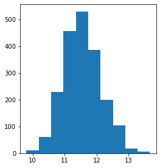

```python
rcParams['figure.figsize'] = 4, 4.5
# look at the numberof cells per spot factors
plt.hist(adata_vis_res.uns['mod']['post_sample_means']['cells_per_spot']);
```

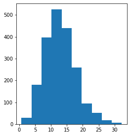

```python
# look at the numberof expressed factors
plt.hist(spot_factors.sum(1));
```

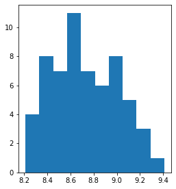

```python
# look at the number of expressed factors
plt.hist(adata_vis_res.uns['mod']['post_sample_means']['factors_per_combs']);
```

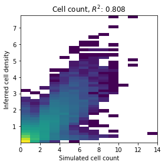

```python
rcParams['figure.figsize'] = 4, 4
rcParams["axes.facecolor"] = "white"

plt.hist2d(cell_count.values.flatten(),
           infer_cell_count.values.flatten(),# / np.mean(adata_vis_res.var['gene_level'].values),
           bins=[cell_count.values.max(), 50], norm=matplotlib.colors.LogNorm());
plt.xlabel('Simulated cell count');
plt.ylabel('Inferred cell density');
plt.title(r'Cell count, $R^2$: ' \
          + str(np.round(np.corrcoef(cell_count.values.flatten(),
           infer_cell_count.values.flatten()), 3)[0,1]));
#plt.gca().set_aspect('equal', adjustable='box')
plt.tight_layout()
plt.savefig(fig_path + '/Cell_density_cor.pdf')
```

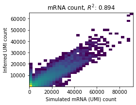

```python
rcParams['figure.figsize'] = 4, 4.5
rcParams["axes.facecolor"] = "white"

plt.hist2d(umi_count.values.flatten(),
           nUMI_factors.values.flatten() \
           / np.mean(adata_vis_res.var['gene_level'].values),
           bins=[35, 41], norm=matplotlib.colors.LogNorm());
plt.xlabel('Simulated mRNA (UMI) count');
plt.ylabel('Inferred UMI count');
plt.title('mRNA count, $R^2$: ' \
          + str(np.round(np.corrcoef(umi_count.values.flatten(),
           nUMI_factors.values.flatten()), 3)[0,1]));
plt.gca().set_aspect('equal', adjustable='box')
plt.tight_layout()
plt.savefig(fig_path + '/nUMI_count_cor.pdf')
```

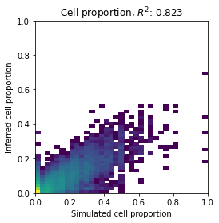

```python
cell_proportions = (cell_count.T / cell_count.sum(1)).T
cell_proportions.iloc[np.isnan(cell_proportions.values)] = 0
infer_cell_proportions = (infer_cell_count.T / infer_cell_count.sum(1)).T

rcParams['figure.figsize'] = 4, 4
plt.hist2d(cell_proportions.values.flatten(),
           infer_cell_proportions.values.flatten(),
           bins=[35, 41], norm=matplotlib.colors.LogNorm());
plt.xlabel('Simulated cell proportion');
plt.ylabel('Inferred cell proportion');
plt.title('Cell proportion, $R^2$: ' \
          + str(np.round(np.corrcoef(cell_proportions.values.flatten(),
           infer_cell_proportions.values.flatten()), 3)[0,1]));
plt.gca().set_aspect('equal', adjustable='box')
plt.xlim(0, 1);
plt.ylim(0, 1);
plt.tight_layout()
plt.savefig(fig_path + '/Cell_proportion_cor.pdf')
```

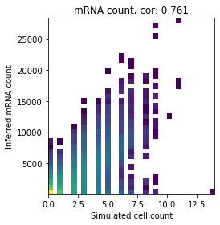

```python
rcParams['figure.figsize'] = 4, 4
plt.hist2d(cell_count.values.flatten(),
           infer_nUMI_count.values.flatten(),
           bins=35, norm=matplotlib.colors.LogNorm());
plt.xlabel('Simulated cell count');
plt.ylabel('Inferred mRNA count');
plt.title('mRNA count, cor: ' \
          + str(np.round(np.corrcoef(cell_count.values.flatten(),
           infer_nUMI_count.values.flatten()), 3)[0,1]));
plt.tight_layout();
#plt.savefig(fig_path + '/mRNA_count_cor.pdf')
```

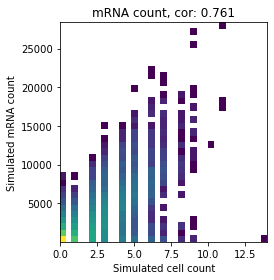

```python
rcParams['figure.figsize'] = 4, 4
plt.hist2d(cell_count.values.flatten(),
           nUMI_factors.values.flatten(),
           bins=35, norm=matplotlib.colors.LogNorm());
plt.xlabel('Simulated cell count');
plt.ylabel('Simulated mRNA count');
plt.title('mRNA count, cor: ' \
          + str(np.round(np.corrcoef(cell_count.values.flatten(),
           infer_nUMI_count.values.flatten()), 3)[0,1]));
plt.tight_layout();
#plt.savefig(fig_path + '/mRNA_count_cor.pdf')
```

```python
def compute_precision_recall(pos_cell_count, infer_cell_proportions):
    r""" Plot precision-recall curves on average and for each cell type.
    :param pos_cell_count: binary matrix showing which cell types are present in which locations
    :param infer_cell_proportions: inferred locations (the higher the more cells)
    """

    from sklearn.metrics import precision_recall_curve
    from sklearn.metrics import average_precision_score

    ### calculating ###
    predictor = infer_cell_proportions.values
    # For each cell type
    precision = dict()
    recall = dict()
    average_precision = dict()
    for i, c in enumerate(infer_cell_proportions.columns):
        precision[c], recall[c], _ = precision_recall_curve(pos_cell_count[:, i],
                                                            predictor[:, i])
        average_precision[c] = average_precision_score(pos_cell_count[:, i], predictor[:, i])

    # A "micro-average": quantifying score on all classes jointly
    precision["micro"], recall["micro"], _ = precision_recall_curve(pos_cell_count.ravel(),
                                                                    predictor.ravel())
    average_precision["micro"] = average_precision_score(pos_cell_count, predictor,
                                                         average="micro")

    return precision, recall, average_precision

def plot_precision_recall(pos_cell_count, infer_cell_proportions,
                          title='', iso_f1_curves=False,
                          individual_cell_types=True,
                          save=None):
    r""" Plot precision-recall curves on average and for each cell type.
    :param pos_cell_count: binary matrix showing which cell types are present in which locations
    :param infer_cell_proportions: inferred locations (the higher the more cells)
    :param title: plot title
    :param iso_f1_curves: plot iso curves for F1 score?
    :param individual_cell_types: show precision-recall curves for each cell type?
    """

    ### calculating ###
    precision, recall, average_precision = compute_precision_recall(pos_cell_count,
                                                                    infer_cell_proportions)
    ### plotting ###
    from itertools import cycle
    # setup plot details
    colors = cycle(['navy', 'turquoise', 'darkorange', 'cornflowerblue', 'teal'])

    lines = []
    labels = []

    if iso_f1_curves:
        f_scores = np.linspace(0.2, 0.8, num=4)

        for f_score in f_scores:
            x = np.linspace(0.01, 1)
            y = f_score * x / (2 * x - f_score)
            l, = plt.plot(x[y >= 0], y[y >= 0], color='gray', alpha=0.2)
            plt.annotate('f1={0:0.1f}'.format(f_score), xy=(0.9, y[45] + 0.02))

        lines.append(l)
        labels.append('iso-f1 curves')

    l, = plt.plot(recall["micro"], precision["micro"], color='navy', lw=2)
    lines.append(l)
    labels.append('micro-average Precision-recall (area = {0:0.2f})'
                  ''.format(average_precision["micro"]))

    if individual_cell_types:
        for i, color in zip(infer_cell_proportions.columns, colors):
            l, = plt.plot(recall[i], precision[i], color='gold', lw=1)
            lines.append(l)
        labels.append('Precision-recall for individual cell types')



    fig = plt.gcf()
    fig.subplots_adjust(bottom=0.25)
    plt.xlim([0.0, 1.0])
    plt.ylim([0.0, 1.05])
    plt.xlabel('Recall')
    plt.ylabel('Precision')
    plt.title(title)
    plt.legend(lines, labels, loc=(0, -.18), prop=dict(size=14))

    if save is not None:
        plt.savefig(save)
```

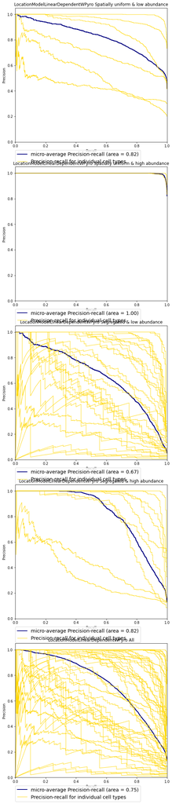

```python
rcParams['figure.figsize'] = 7, 32
rcParams['pdf.fonttype'] = 42
pos_cell_count = cell_count.values > 0

def pr_by_category(pos_cell_count, infer_cell_count, design,
                   nrow=5, ncol=1, title='', fig_path=''):

    design_loc = design.loc[cell_count.columns,:]

    plt.subplot(nrow, ncol, 1)
    ind = (design_loc['uniform'] * design_loc['density']).values.astype(bool)
    plot_precision_recall(pos_cell_count[:, ind], infer_cell_count.loc[:,ind],
                          title=title + ' Spatially uniform & low abundance',
                          #save=fig_path + '/Uniform_low_abundance.pdf'
                         )

    plt.subplot(nrow, ncol, 2)
    ind = (design_loc['uniform'] * (1 - design_loc['density'])).values.astype(bool)
    plot_precision_recall(pos_cell_count[:, ind], infer_cell_count.loc[:,ind],
                          title=title + ' Spatially uniform & high abundance',
                          #save=fig_path + '/Uniform_high_abundance.pdf'
                         )

    plt.subplot(nrow, ncol, 3)
    ind = ((1 - design_loc['uniform']) * design_loc['density']).values.astype(bool)
    plot_precision_recall(pos_cell_count[:, ind], infer_cell_count.loc[:,ind],
                          title=title + ' Segregated & low abundance',
                          #save=fig_path + '/Segregated_low_abundance.pdf'
                         )

    plt.subplot(nrow, ncol, 4)
    ind = ((1 - design_loc['uniform']) * (1 - design_loc['density'])).values.astype(bool)
    plot_precision_recall(pos_cell_count[:, ind], infer_cell_count.loc[:,ind],
                          title=title + ' Segregated & high abundance',
                          #save=fig_path + '/Segregated_high_abundance.pdf'
                         )

    plt.subplot(nrow, ncol, 5)
    plot_precision_recall(pos_cell_count, infer_cell_count,
                          title=title + ' All',
                          #save=fig_path + '/All.pdf'
                         )

pr_by_category(pos_cell_count, infer_cell_count, design,
               nrow=5, ncol=1, title=r['model_name'].__name__,
               fig_path=fig_path)
plt.tight_layout()
plt.savefig(fig_path + '/All.pdf')
```

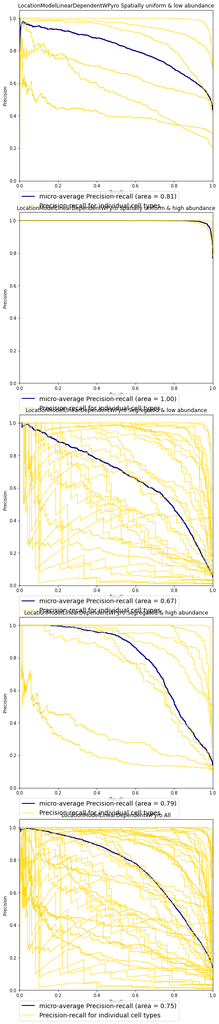

```python
rcParams['figure.figsize'] = 7, 32
rcParams['pdf.fonttype'] = 42
pos_cell_count = cell_count.values > 0

pr_by_category(pos_cell_count, infer_cell_proportions, design,
               nrow=5, ncol=1, title=r['model_name'].__name__,
               fig_path=fig_path)
plt.tight_layout()
```

#### Split results by spatial distribution and abundance of cell types

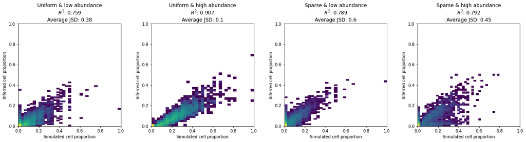

```python
def KL(a, b):
    a = np.asarray(a, dtype=np.float)
    b = np.asarray(b, dtype=np.float)

    return np.sum(np.where(a != 0, a * np.log2(a / b), 0))
from scipy.spatial.distance import jensenshannon

def hist_obs_sim(cell_count, infer_cell_count,
                 xlab='Simulated cell proportion',
                 ylab='Inferred cell proportion',
                 title='', compute_kl=True, equal=True):

    cor = np.round(np.corrcoef(cell_count.values.flatten(),
               infer_cell_count.values.flatten()), 3)[0,1]
    max_val = np.concatenate([cell_count.values.flatten(),
                               infer_cell_count.values.flatten()]).max()
    title = title +'\n'+ r'$R^2$: ' + str(cor)

    if compute_kl:

        #kl = [KL(cell_count.values[r,:], infer_cell_count.values[r,:])
        #         for r in range(cell_count.shape[0])]
        js = np.array([jensenshannon(cell_count.values[r,:], infer_cell_count.values[r,:])
                 for r in range(cell_count.shape[0])])
        #kl = np.mean(kl)
        js = np.mean(js[~np.isnan(js)])
        #title = title + '\nAverage KL: ' + str(np.round(kl, 2))
        title = title + '\nAverage JSD: ' + str(np.round(js, 2))

    if np.max(cell_count.values) > 1:
        x_bins = np.max(cell_count.values)
        max_val = None
    else:
        x_bins = 35
        max_val = 1

    plt.hist2d(cell_count.values.flatten(),
               infer_cell_count.values.flatten(),
               bins=[x_bins, 35], norm=matplotlib.colors.LogNorm());
    plt.xlabel(xlab);
    plt.ylabel(ylab);
    if equal:
        plt.gca().set_aspect('equal', adjustable='box')
    plt.xlim(0, max_val);
    plt.ylim(0, max_val);
    plt.title(title);

def hist_by_category(cell_count, infer_cell_count, design,
                 xlab='Simulated cell proportion',
                 ylab='Inferred cell proportion',
                 nrow=1, ncol=4, compute_kl=True, equal=True):

    design_loc = design.loc[cell_count.columns,:]

    plt.subplot(nrow, ncol, 1)
    ind = (design_loc['uniform'] * design_loc['density']).values.astype(bool)
    hist_obs_sim(cell_count.loc[:,ind], infer_cell_count.loc[:,ind],
                 xlab=xlab,
                 ylab=ylab,
                 title='Uniform & low abundance',
                 compute_kl=compute_kl, equal=equal)

    plt.subplot(nrow, ncol, 2)
    ind = (design_loc['uniform'] * (1 - design_loc['density'])).values.astype(bool)
    hist_obs_sim(cell_count.loc[:,ind], infer_cell_count.loc[:,ind],
                 xlab=xlab,
                 ylab=ylab,
                 title='Uniform & high abundance',
                 compute_kl=compute_kl, equal=equal)

    plt.subplot(nrow, ncol, 3)
    ind = ((1 - design_loc['uniform']) * design_loc['density']).values.astype(bool)
    hist_obs_sim(cell_count.loc[:,ind], infer_cell_count.loc[:,ind],
                 xlab=xlab,
                 ylab=ylab,
                 title='Sparse & low abundance',
                 compute_kl=compute_kl, equal=equal)

    plt.subplot(nrow, ncol, 4)
    ind = ((1 - design_loc['uniform']) * (1 - design_loc['density'])).values.astype(bool)
    hist_obs_sim(cell_count.loc[:,ind], infer_cell_count.loc[:,ind],
                 xlab=xlab,
                 ylab=ylab,
                 title='Sparse & high abundance',
                 compute_kl=compute_kl, equal=equal)

cell_proportions = (cell_count.T / cell_count.sum(1)).T
cell_proportions.iloc[np.isnan(cell_proportions.values)] = 0
infer_cell_proportions = (infer_cell_count.T / infer_cell_count.sum(1)).T

rcParams['figure.figsize'] = 18,4.5 #9,9 #20, 4.5
rcParams["axes.facecolor"] = "white"
hist_by_category(cell_proportions, infer_cell_proportions, design,
                 xlab='Simulated cell proportion',
                 ylab='Inferred cell proportion',
                 #compute_kl=False,
                 nrow=1, ncol=4, equal=True)
plt.tight_layout()

plt.savefig(fig_path + '/hist_by_category.pdf')
```

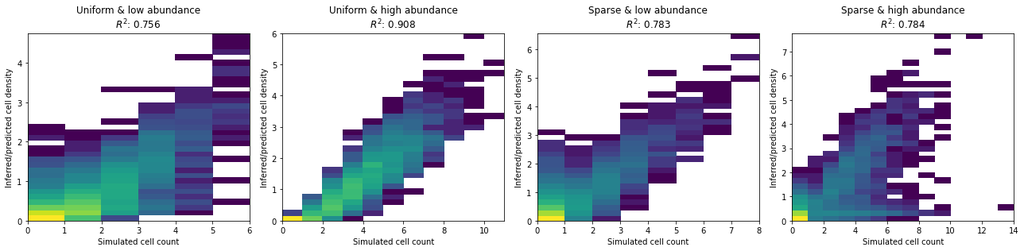

```python
rcParams['figure.figsize'] = 18, 4.5
rcParams["axes.facecolor"] = "white"
hist_by_category(cell_count, infer_cell_count, design,
                 xlab='Simulated cell count',
                 ylab='Inferred/predicted cell density',
                 compute_kl=False, equal=False)
plt.tight_layout()
plt.savefig(fig_path + '/hist_density_by_category.pdf')
```

plt.hist(adata_vis_res.uns['mod']['post_sample_means']['factors_per_spot'].flatten());

plt.hist(adata_vis_res.uns['mod']['post_sample_means']['combs_per_spot'].flatten());

combs_factors_df = pd.DataFrame(adata_vis_res.uns['mod']['post_sample_means']['combs*factors'], columns=['comb*' + str(i) for i in range(adata_vis_res.uns['mod']['post_sample_means']['combs_factors'].shape[1])]) combs_factors_df

from cell2location.plt.plot_heatmap import clustermap comb2fact_df = pd.DataFrame(adata_vis_res.uns['mod']['post_sample_means']['comb2fact'], columns=adata_vis_res.uns['mod']['fact_names']) comb2fact_df_prop = (comb2fact_df / comb2fact_df.sum(0)) clustermap(comb2fact_df) clustermap(comb2fact_df_prop)

plt.hist(adata_vis_res.uns['mod']['post_sample_means']['p_per_spot'].flatten());plt.hist(adata_vis_res.uns['mod']['post_sample_means']['shape_per_factor'].flatten());p = adata_vis_res.uns['mod']['post_sample_means']['factors_per_spot'] shape = 1 / (adata_vis_res.uns['mod']['post_sample_means']['shape_per_factor'] \ * adata_vis_res.uns['mod']['post_sample_means']['shape_per_factor']) rate = 1 / adata_vis_res.uns['mod']['post_sample_means']['cells_per_spot']\ * p * 41 mean = (shape / rate) * p plt.hist(mean.flatten());

#### Stratify cell types by their size in the reference

```python
gene_factors = pd.DataFrame(adata_vis_res.uns['mod']['post_sample_means']['gene_factors'],
                            index=adata_vis_res.uns['mod']['var_names'],
                            columns=adata_vis_res.uns['mod']['fact_names'])
```

```
Index(['Astro_0', 'Astro_1', 'Astro_2', 'Astro_3', 'Astro_4', 'Micro', 'Nb_1',
       'Nb_2', 'Oligo_2', 'Unk_1'],
      dtype='object')
```

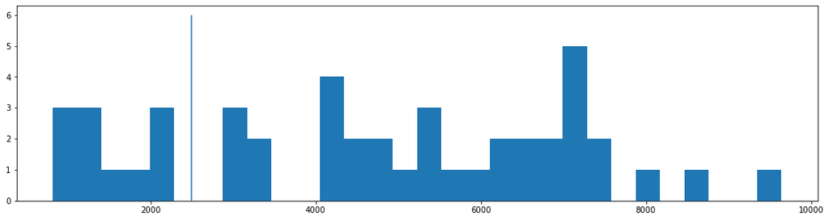

```python
plt.hist(gene_factors.sum(0), bins=30);
plt.vlines(2500, 0, 6);
small_ind = np.array(gene_factors.sum(0) < 2500) & (design['density']).values.astype(bool)
gene_factors.columns[small_ind]
```

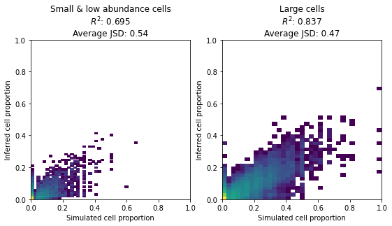

```python
def hist_by_category2(cell_count, infer_cell_count, index,
                 xlab='Simulated cell proportion',
                 ylab='Inferred cell proportion',
                 name1='', name2='',
                 nrow=1, ncol=4, compute_kl=True, equal=True):

    design_loc = design.loc[cell_count.columns,:]

    plt.subplot(nrow, ncol, 1)
    hist_obs_sim(cell_count.loc[:,index], infer_cell_count.loc[:,index.astype(bool)],
                 xlab=xlab,
                 ylab=ylab,
                 title=name1,
                 compute_kl=compute_kl, equal=equal)

    plt.subplot(nrow, ncol, 2)
    hist_obs_sim(cell_count.loc[:,~index], infer_cell_count.loc[:,~index.astype(bool)],
                 xlab=xlab,
                 ylab=ylab,
                 title=name2,
                 compute_kl=compute_kl, equal=equal)

rcParams['figure.figsize'] = 9, 4.5
rcParams["axes.facecolor"] = "white"

hist_by_category2(cell_proportions, infer_cell_proportions, small_ind,
                 xlab='Simulated cell proportion',
                 ylab='Inferred cell proportion',
                 name1='Small & low abundance cells', name2='Large cells',
                 nrow=1, ncol=2, compute_kl=True)
```

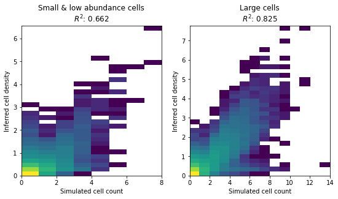

```python
hist_by_category2(cell_count, infer_cell_count, small_ind,
                 xlab='Simulated cell count',
                 ylab='Inferred cell density',
                 name1='Small & low abundance cells', name2='Large cells',
                 nrow=1, ncol=2, compute_kl=False, equal=False)
```

### Evaluate inferred gene expression level difference between technologies (`gene_level`)

```python
gene_level = pd.DataFrame(adata_vis_res.uns['mod']['post_sample_means']['gene_level'].flatten(),
                 index=adata_vis_res.uns['mod']['var_names'],
                 columns=['inferred_gene_level'])
adata_vis_res.var['inferred_gene_level'] = gene_level.reindex(index=adata_vis_res.var_names)['inferred_gene_level']
```

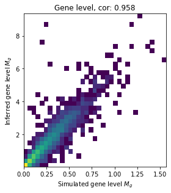

```python
rcParams['figure.figsize'] = 4, 4.5
var = adata_vis_res.var
var = var.loc[~var['inferred_gene_level'].isna(),:]
plt.hist2d(var['gene_level'].values.flatten() / 5,
           var['inferred_gene_level'].values.flatten(),
           bins=35, norm=matplotlib.colors.LogNorm());
plt.xlabel(r'Simulated gene level $M_g$');
plt.ylabel('Inferred gene level $M_g$');
#plt.xlim(0, 1);
#plt.ylim(0, 1);
plt.title('Gene level, cor: ' \
          + str(np.round(np.corrcoef(var['gene_level'].values.flatten(),
                var['inferred_gene_level'].values.flatten()), 3)[0,1]));
plt.tight_layout();
plt.savefig(fig_path + '/hist_gene_level.pdf')
```

## Tracking logp

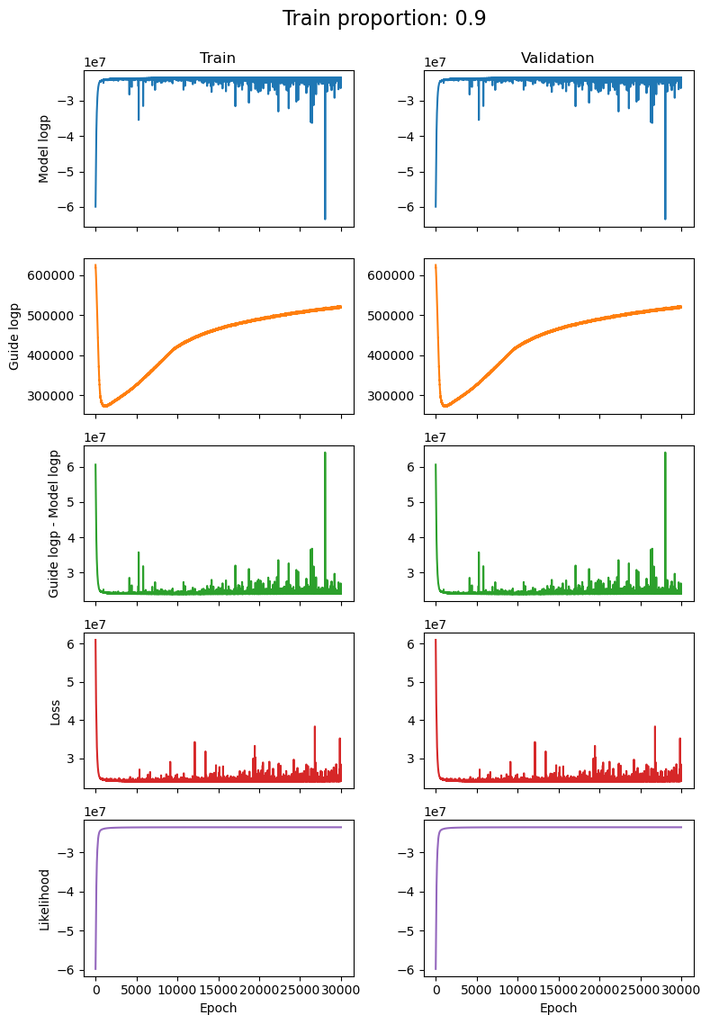

```python
reg_mod = r1['mod']

fig, axs = plt.subplots(nrows=5, ncols=2, sharex=True, figsize=(8, 11))

init = 'init_1'
train_proportion = 0.9

col_enum = {0: reg_mod.logp_hist[init],
            1: reg_mod.logp_hist[init]}

first_n = 30000

for row_num, row in enumerate(axs):
    for col_num, ax in enumerate(row):
        data = col_enum[col_num]

        if ax.is_last_row():
            ax.set_xlabel('Epoch')

        if ax.is_first_row():
            if col_num == 0:
                ax.set_title('Train')
            if col_num == 1:
                ax.set_title('Validation')

        if row_num == 0:
            ax.plot(data['model'][:first_n], color='C0')
            if ax.is_first_col():
                ax.set_ylabel('Model logp')

        if row_num == 1:
            ax.plot(data['guide'][:first_n], color='C1')
            if ax.is_first_col():
                ax.set_ylabel('Guide logp')

        if row_num == 2:
            ax.plot(-(np.array(data['model']) - np.array(data['guide']))[:first_n], color='C2')
            if ax.is_first_col():
                ax.set_ylabel('Guide logp - Model logp')

        if row_num == 3:
            if col_num == 0:
                ax.plot(reg_mod.hist[init][:first_n], color='C3')
            if col_num == 1:
                ax.plot(reg_mod.hist[init][:first_n], color='C3')
            if ax.is_first_col():
                ax.set_ylabel('Loss')

        if row_num == 4:
            ax.plot(data['data_target'][:first_n], color='C4')
            if ax.is_first_col():
                ax.set_ylabel('Likelihood')

plt.tight_layout()

plt.suptitle(f'Train proportion: {train_proportion}', y=1.03, x=0.54, size=16);
# plt.savefig(f'train_prop_{train_proportion}_logp_w_0.33.png', dpi=250, bbox_inches='tight')
```

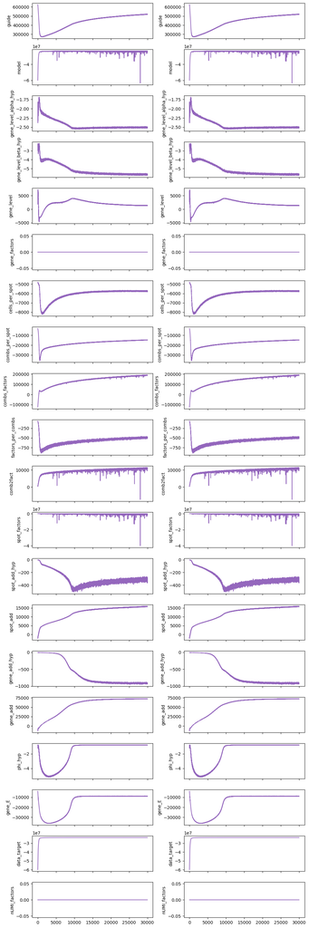

```python
rcParams['figure.figsize'] = 7, 20

matplotlib.rc_file_defaults()
with matplotlib.rc_context({'figure.figsize': (7, 50),
                            'savefig.facecolor': 'white'}):

    init = 'init_1'
    train_proportion = 0.9

    col_enum = {0: reg_mod.logp_hist[init].copy(),
                1: reg_mod.logp_hist[init].copy()}

    first_n = 30000

    param_name = list(reg_mod.logp_hist[init].keys())
    param_name = np.array(param_name)[[type(i) == str for i in param_name]]

    fig, axs = plt.subplots(nrows=len(param_name),
                            ncols=2, sharex=True, figsize=(10, 30))

    for row_num, row in enumerate(axs):
        for col_num, ax in enumerate(row):
            data = col_enum[col_num]
            ax.plot(data[param_name[row_num]][:first_n], color='C4')
            ax.set_ylabel(param_name[row_num])

    plt.tight_layout()
```

### Compare the models using precision-recall

```python
def compare_precision_recall(pos_cell_count, infer_cell_proportions,
                             method_title, title='',
                             legend_loc=(0, -.18),
                             colors=['navy', 'turquoise', 'darkorange', 'cornflowerblue', 'teal']):

    r""" Plot precision-recall curves on average and for each cell type.
    :param pos_cell_count: binary matrix showing which cell types are present in which locations
    :param infer_cell_proportions: inferred locations (the higher the more cells),
                                        list of inferred parameters for several methods
    :param method_title: title for each infer_cell_proportions
    :param title: plot title
    """
    # setup plot details
    from itertools import cycle
    colors = cycle(colors)
    lines = []
    labels = []
    roc = {}

    ### plotting ###
    for i, color in zip(range(len(infer_cell_proportions)), colors):

        precision, recall, average_precision = compute_precision_recall(pos_cell_count,
                                                                    infer_cell_proportions[i])
        l, = plt.plot(recall["micro"], precision["micro"], color=color, lw=3)
        lines.append(l)

        labels.append(method_title[i] + ' (area = {0:0.2f})'
                  ''.format(average_precision["micro"]))
        roc[method_title[i]] = average_precision["micro"]


    fig = plt.gcf()
    fig.subplots_adjust(bottom=0.25)
    plt.xlim([0.0, 1.0])
    plt.ylim([0.0, 1.05])
    plt.xlabel('Recall')
    plt.ylabel('Precision')
    plt.title(title)
    if legend_loc is not None:
        plt.legend(lines, labels, loc=legend_loc, prop=dict(size=14))

    #plt.show()
    return roc

def read_cell_maps(results_folder, run_name, cell_count, post_type='mean'):

    # read anndata object, extract data
    sp_data_file = results_folder + run_name + '/sp.h5ad'
    adata_vis_res = anndata.read(sp_data_file)

    # read pickle with extra info
    file = results_folder + run_name+'/model_.p'
    r = pickle.load(file = open(file, "rb"))

    # extract data
    from re import sub
    cell_count_columns = [sub('ref_', '', i) for i in cell_count.columns]

    spot_factors = adata_vis_res.obs[[post_type + '_spot_factors' + i for i in cell_count_columns]]
    spot_factors.columns =  ['ref_' + sub(post_type + '_spot_factors', '', i) for i in spot_factors.columns]

    #spot_factors_sd = adata_vis_res.obs[['sd_spot_factors' + i for i in cell_count_columns]]
    #spot_factors_sd.columns =  ['ref_' + sub('sd_spot_factors', '', i) for i in spot_factors_sd.columns]

    nUMI_factors = adata_vis_res.obs[[post_type + '_nUMI_factors' + i for i in cell_count_columns]]
    nUMI_factors.columns =  [sub(post_type + '_nUMI_factors', 'ref_', i) for i in nUMI_factors.columns]

    #spot_factors = spot_factors / spot_factors_sd

    infer_cell_count = spot_factors[cell_count.columns]
    infer_nUMI_count = nUMI_factors[cell_count.columns]

    infer_cell_proportions = (infer_cell_count.T / infer_cell_count.sum(1)).T

    return r['model_name'], infer_cell_proportions, infer_cell_count, infer_nUMI_count # spot_factors_sd
```

names = [] results = [] names_count = [] results_count = [] results_q05 = [] results_count_q05 = []

run_names = [

```
#'CoLocationModelNB4V6_V2_46clusters_2000locations_19605genes_n_comb60_mean_var05_ceps9_cps4_fps5_inf_shape01',
'LocationModelNB4V7_V4_V4_46clusters_2000locations_19605genes_n_comb30_mean_var05_ceps9_cps2_fps5_inf_shape01',

# testing gene selection and the regression model
'CoLocationModelNB4V2_46clusters_2000locations_19605genes_n_comb30_mean_var05_ceps9_cps2_fps5_inf_shape01',
'CoLocationModelNB4V2_46clusters_2000locations_12281genes_n_comb30_mean_var05_ceps9_cps2_fps5_shape01',
'CoLocationModelNB4V2_46clusters_2000locations_12281genes_n_comb30_mean_var05_ceps9_cps2_fps5_inf_shape01',

# varying levels of downsampling (2, 1, 4, 8)
'CoLocationModelNB4V2_46clusters_2000locations_12281genes_n_comb60_lr0005_n_iter30k_mean_var5_ceps9_cps4_fps5_inf_shape01',
'CoLocationModelNB4V2_46clusters_2000locations_12281genes_n_comb60_lr0005_n_iter30k_mean_var5_ceps9_cps4_fps5_inf_shape01_gl1',
'CoLocationModelNB4V2_46clusters_2000locations_12281genes_n_comb60_lr0005_n_iter30k_mean_var5_ceps9_cps4_fps5_inf_shape01_gl4',
'CoLocationModelNB4V2_46clusters_2000locations_12281genes_n_comb60_lr0005_n_iter30k_mean_var5_ceps9_cps4_fps5_inf_shape01_gl8',
        ]
```

```
#infer_cell_count = (infer_cell_count.T / infer_cell_count.max(1)).T
names.append(name)
results.append(infer_cell_prop)
names_count.append(name)
results_count.append(infer_cell_count)

name, infer_cell_prop, infer_cell_count, _ = \
read_cell_maps(results_folder + 'models/', n, cell_count, post_type='q05')
#infer_cell_count = (infer_cell_count.T / infer_cell_count.max(1)).T
results_q05.append(infer_cell_prop)
results_count_q05.append(infer_cell_count)
```

names

names[1] = names[1] + ' Inferred, no gene selection' names[2] = names[2] + ' Gene selection' names[3] = names[3] + ' Inferred & gene selection'

# names[0] = names[0].**name** + ' learned Co-Loc'

names[4] = names[4] + ' '

names

names_add = ['VI', 'VI', 'VI', 'w/ inferred ref', 'VI', 'MAP'] names = [names[n] + ', ' + names_add[n] for n in range(len(names))] names_add = ['VI', 'VI', 'VI', 'w/ inferred ref', 'VI'] names_count = [names_count[n] + ', ' + names_add[n] for n in range(len(names_count))]

rcParams['figure.figsize'] = 15, 8 rcParams['font.size'] = 16 compare_precision_recall(pos_cell_count, results, method_title=names, legend_loc=(1.1, 0.5)) plt.tight_layout()

# plt.savefig(fig_path + '/ROC_comparison_all.pdf')

#### Compares using RMSE on proportions

from sklearn.metrics import mean_squared_error rmse = pd.DataFrame() for i in range(len(results)): rmse[names[i]] = ((cell_proportions - results[i]) ** 2).mean(1)

rcParams['figure.figsize'] = 15, 5 sns.boxplot(data=rmse, orient="h").set( xlabel='Root mean squared error' ) plt.tight_layout() plt.savefig(fig_path + '/RMSE_comparison_all.pdf') plt.show()